# Berlin

## Neueinstellungen

## Entwicklung

- Seit 02.01.2018 wurden in Berlin 5007 AirBnB Wohnungen eingestellt.
- **Einstellungen von AirBnB Wohnungen haben im letzten Jahr stark zugenommen. Im Jahr 2019 wurden insgesamt 3274 neue Wohnungen eingestellt, wohingegend im Jahr 2018 nur 1733 Wohnungen eingestellt wurden. Dies entspricht einem Zuwachs von 89%.**
- Von diesen Wohnungen weisen aktuell 73% Verfügbarkeiten von durchschnittlich 47.5 Tagen für die nächsten 3 Monate auf.

## Entwicklung

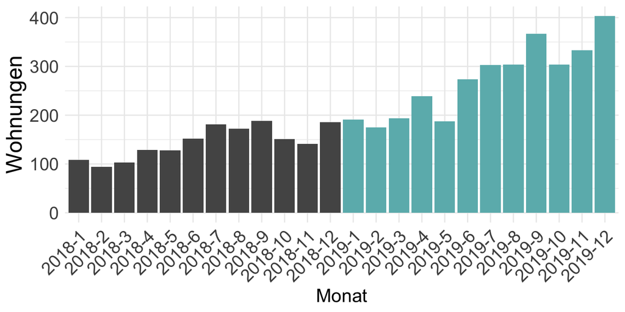

Figure 1. Neueinstellungen pro Monat.

## Stadtteile

[output not shown]

## Stadtteile

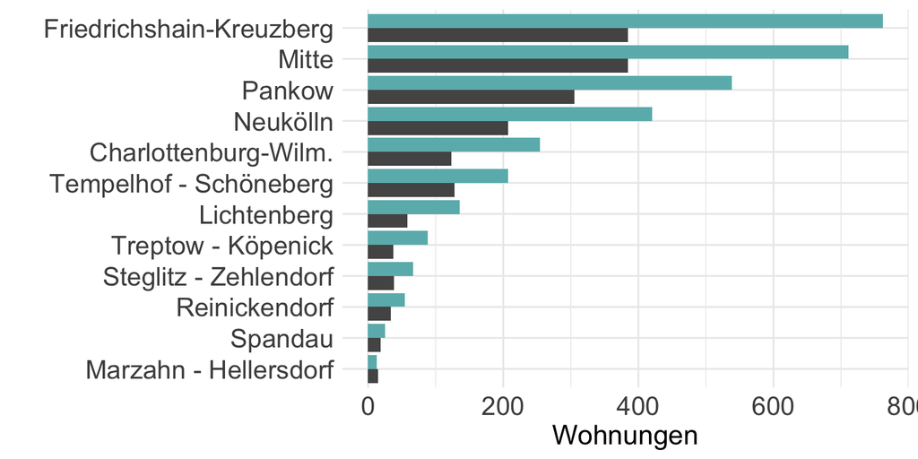

Figure 2. Neueinstellungen pro Bezirk

## Preis

## Einfluss der Ausstattung

Tabelle 1. Austtatung und Einfluss auf den Preis

|  | Preis Nicht-vorh. | Preis vorh. | Differenz | Prozent vorh. |
| --- | --- | --- | --- | --- |
| Check_in_24h | 79.9 | 152.8 | 72.9 | 1.3 |
| TV | 62.5 | 100.6 | 38.2 | 48.2 |
| Wifi | 56.3 | 81.7 | 25.3 | 96.7 |
| Terrasse_Balkon | 76.1 | 92.9 | 16.8 | 28 |
| Geschirrspüler | 78.5 | 85 | 6.5 | 36.3 |
| Kaffeemaschine | 80.5 | 81.2 | 0.7 | 50.5 |
| Küche | 162.3 | 73.4 | -88.9 | 91.7 |

**Der stark negative Effekt der Küche überrascht. Er könnte durch die Art der Unterkunft moderiert werden, gegeben dass auch Hotels im Angebot enthalten sind.**

## Regressionsmodell

Tabelle 2. Regression des Preises auf die Ausstattung.

Preis

Predictors

CI

Estimates

Achsenabschnitt

68.95 – 111.21

90.08 ***

Hotel

384.88 – 489.79

437.34 ***

Küche

-59.50 – -16.40

-37.95 ***

TV

16.67 – 39.47

28.07 ***

Terrasse_Balkon

8.06 – 33.35

20.71 **

Check_in_24h

-7.81 – 92.02

42.11

Observations

5007

R<sup>2</sup> / R<sup>2</sup> adjusted

0.074 / 0.073

- p<0.05 ** p<0.01 *** p<0.001